# Ezekiel_ESS______New species added

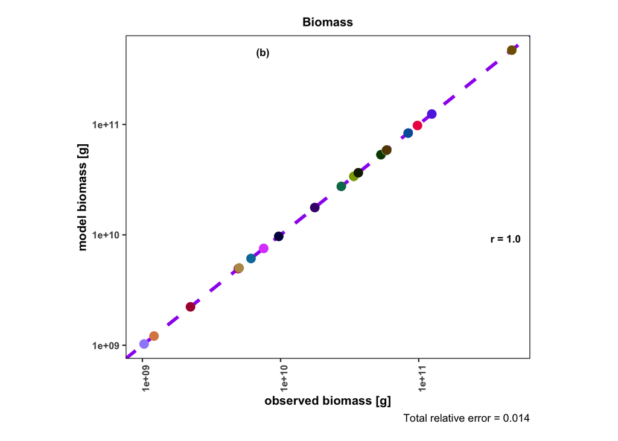

```r
biomass_steady<-plotBiomassObservedVsModel(params_steady, return_data=T)
r_biomass<-cor(biomass_steady$model,biomass_steady$observed,method="spearman")

Calibration_plot_biomass <- plotBiomassObservedVsModel(params_steady, ratio = FALSE, labels = FALSE) +
  theme_bw() +
    ggtitle("Biomass") +  # Adding the title
    theme(
        plot.title = element_text(size = 10, face = "bold", hjust = 0.5),  # Centering the title
        axis.text.x = element_text(angle = 90, hjust = 1, vjust = 1, size = 8, face = "bold"),
        axis.text.y = element_text(size = 8, face = "bold"),  # Y-axis labels size 8
        axis.title.x = element_text(size = 10, face = "bold"),  # X-axis title size 8
        axis.title.y = element_text(size = 10, face = "bold"),  # Y-axis title size 8
        panel.grid.major.x = element_blank(),
        panel.grid.major.y = element_blank(),
        panel.grid.minor = element_blank(),
        panel.border = element_rect(color = "black", size = 0.5),
        legend.position = "none",  # No legend since all bars are blue
        panel.spacing = unit(0.5, "lines"),
        plot.margin = unit(c(0.5, 0.5, 0.5, 0.2), "cm"),
        aspect.ratio = 0.8 ) +
    geom_hline(yintercept = 0, color = "black", size = 0.1)+
    annotate("text", x = Inf, y = Inf, label = expression(bold("(b)")),
         parse = TRUE, size = 3, hjust = 20.5, vjust = 2.3) +
    annotate("text", x = Inf, y = Inf, label = expression(bold("r = 1.0")),
         parse = TRUE, size = 3, hjust = 1.3, vjust = 27.1)
# Display the plot

print(Calibration_plot_biomass)
```

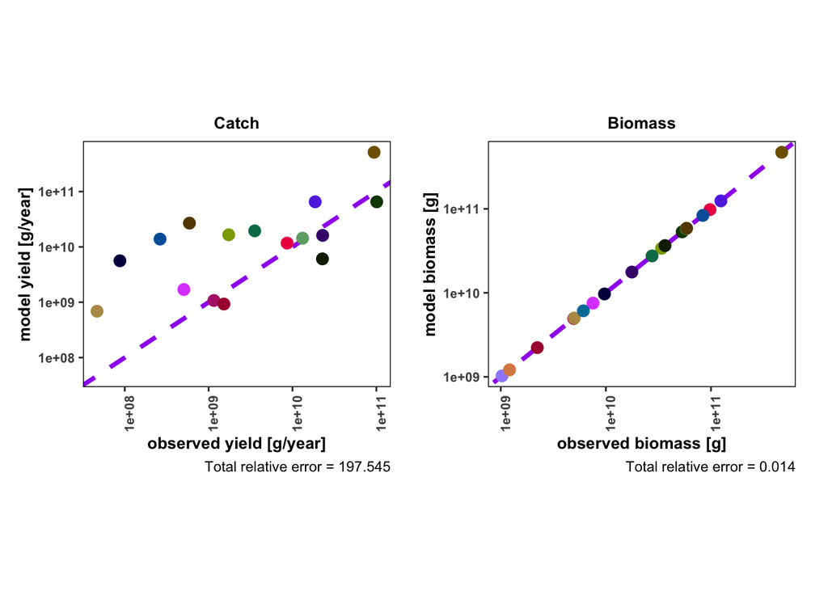

```r
Calibration_plot_yield+Calibration_plot_biomass
```

```r
combined_plot <- Calibration_plot_yield + Calibration_plot_biomass +
  plot_layout(nrow = 1)
```

Plot Observed vs model error calibration period

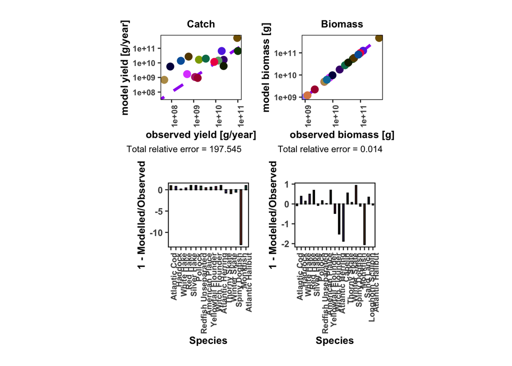

```r
library(ggplot2)
library(forcats)
library(patchwork)

# ------------------------------------------------------------
# Shared colour palette for 16 species
# ------------------------------------------------------------
species_colours <- c(
  "#815f00", "#6237e2", "#8da600", "#de53ff", "#0e4300",
  "#430079", "#6caa72", "#ee0053", "#007957", "#b42979",
  "#142300", "#a08dfb", "#644500", "#00b4d8", "#e76f51",
  "#2a9d8f", "#f4a261", "#457b9d", "#e9c46a")

# ------------------------------------------------------------
# Shared theme
# ------------------------------------------------------------
calibration_theme <- theme_bw() +
  theme(
    axis.text.x     = element_text(angle = 90, hjust = 1, vjust = 1, face = "bold", size = 8),
    axis.text.y     = element_text(face = "bold", size = 9),
    panel.grid      = element_blank(),
    panel.border    = element_rect(color = "black", linewidth = 0.8),
    axis.title      = element_text(size = 10, face = "bold"),
    legend.position = "none",
    panel.spacing   = unit(0.5, "lines"),
    plot.margin     = unit(c(0.5, 0.5, 0.5, 0.2), "cm"),
    aspect.ratio    = 0.8)

# ------------------------------------------------------------
# 1. Yield plot
# ------------------------------------------------------------
Calibration_pb_yield <- plotYieldObservedVsModel(params, ratio = FALSE, labels = FALSE, return_data = TRUE)

pb_yield <- mean(1 - Calibration_pb_yield$ratio, na.rm = TRUE)

Calibration_plot_Y <- ggplot(
  Calibration_pb_yield,
  aes(x = species, y = 1 - ratio, fill = species)) +
  geom_bar(stat = "identity", position = "dodge", width = 0.3, color = "black") +
  scale_fill_manual(values = species_colours) +
  geom_hline(yintercept = 0, color = "black", linewidth = 0.1) +
  annotate("text", x = Inf, y = Inf,label = expression(bold("(c)")),
  parse = TRUE, size = 3, hjust = 21.5, vjust = 2.1) +
  labs(x = "Species", y = "1 - Modelled/Observed") +
  calibration_theme

# ------------------------------------------------------------
# 2. Biomass plot
# ------------------------------------------------------------
Calibration_pb_biomass <- plotBiomassObservedVsModel(params, ratio = FALSE, labels = FALSE, return_data = TRUE)

pb_biomass <- mean(1 - Calibration_pb_biomass$ratio, na.rm = TRUE)

Calibration_plot_B <- ggplot(
  Calibration_pb_biomass,
  aes(x = species, y = 1 - ratio, fill = species)) +
  geom_bar(stat = "identity", position = "dodge", width = 0.3, color = "black") +
  scale_fill_manual(values = species_colours) +
  geom_hline(yintercept = 0, color = "black", linewidth = 0.1) +
  annotate("text",
    x     = length(unique(Calibration_pb_biomass$species)) + 0.5,
    y     = max(1 - Calibration_pb_biomass$ratio, na.rm = TRUE),
    label = expression(bold("(d)")),
    parse = TRUE, size = 3, hjust = 20.5, vjust = 1.1) +
  labs(x = "Species", y = "1 - Modelled/Observed") +
  calibration_theme

# ------------------------------------------------------------
# 3. Combined plot
# ------------------------------------------------------------
Calibration_plot <- combined_plot / (Calibration_plot_Y + Calibration_plot_B)
Calibration_plot
```

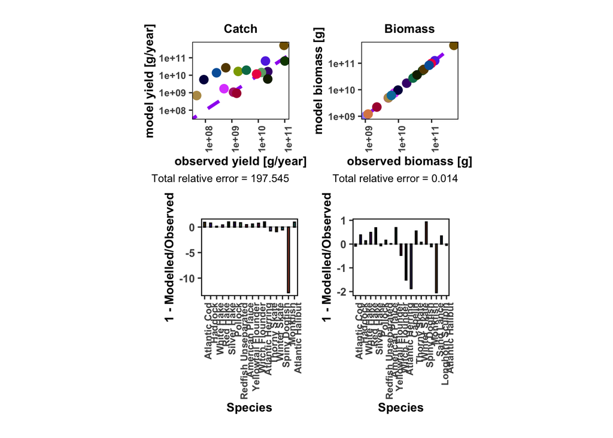

```r
ggsave(filename = paste0(save_dir, "Calibration_plot.jpeg"), plot = Calibration_plot,
       width = 11,height = 8.5, units = "in",dpi = 400)
Calibration_plot
```

## Check plots with time series effort forcing on

Run the model with changing fishing through time

```r
fishing_history <- read.csv("Ess_data/effort_gear_with_seals.csv")
# Subset by Year column, then assign years as row names
effort_df <- fishing_history[fishing_history$Year %in% 1978:2024,
                              c("Bottom_Trawl", "Fixed_Gear", "Small_Mesh", "Pelagic", "Seals")]
effort <- as.matrix(effort_df)
rownames(effort) <- as.numeric(fishing_history$Year[fishing_history$Year %in% 1978:2024])
#storage.mode(effort) <- "numeric"

# Spin up and project
params_spin <- projectToSteady(params_steady, effort = initial_effort(params), t_max = 100)
```

```
## Convergence was achieved in 1.5 years.
```

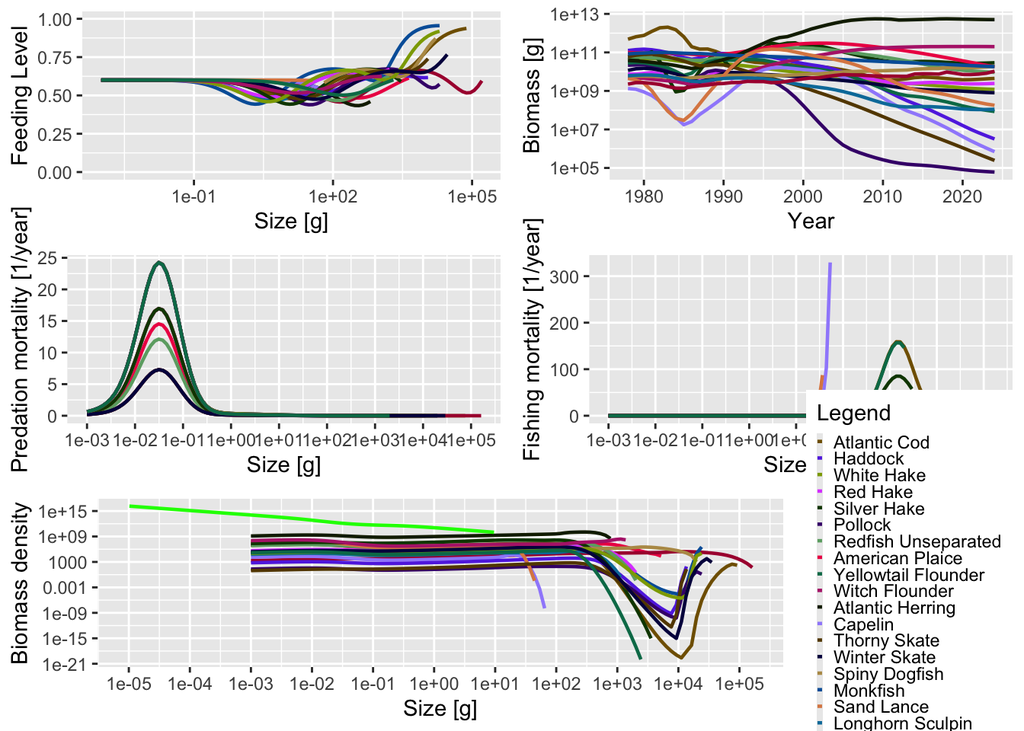

```r
sim <- project(params_spin, effort = effort)
plot(sim)
```

```r
saveRDS(params_steady,"Ess_data/new_params_with_seal_interaction.RDS")
```

# Exploratory Run of Projection through Time

Now, assess how the full model looks compared with time series data in the reference period only. Should calculate some statistical goodness of fit metrics here

Get modelled biomass, excluding sizes < biomass_cutoff g to be consistent with the survey biomasses

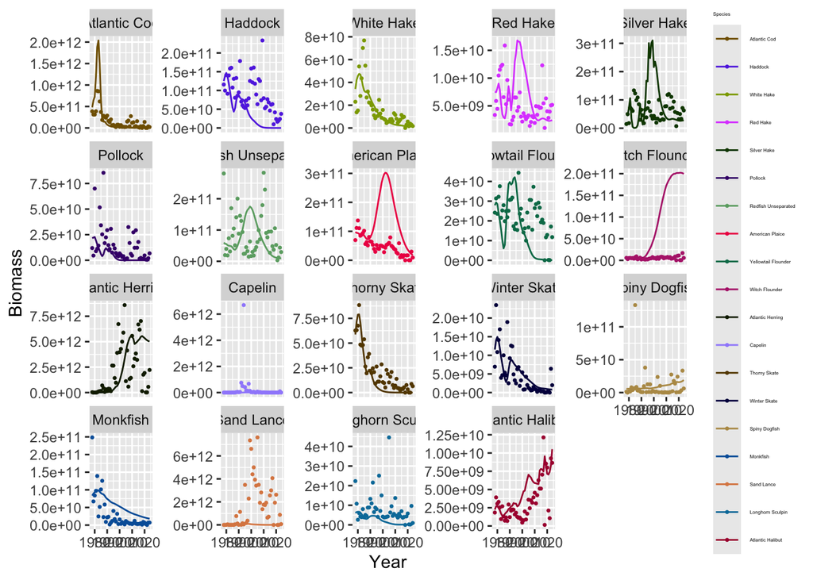

```r
biomass_sim_base<-getBiomass(sim,min_w=10)
biomass_sim_base<-melt(biomass_sim_base,id.vars=1)
names(biomass_sim_base)<-c("Year", "Species","Biomass")


# filter() with no condition does nothing — specify the year range for both
ggplot(filter(biomass_sim_base, Year <= 2024),
       aes(x = Year, y = Biomass, group = Species)) +
  geom_line(aes(colour = Species)) +
  facet_wrap(~ Species, scales = "free_y") +
  geom_point(data = filter(biomass_ts, Year <= 2024),
             aes(x = Year, y = Biomass, colour = Species), size = 0.5) +
  theme(legend.title = element_text(size = 3),
        legend.text  = element_text(size = 3)) +
  scale_colour_manual(values = params@linecolour)
```

Make plots  
plot yields

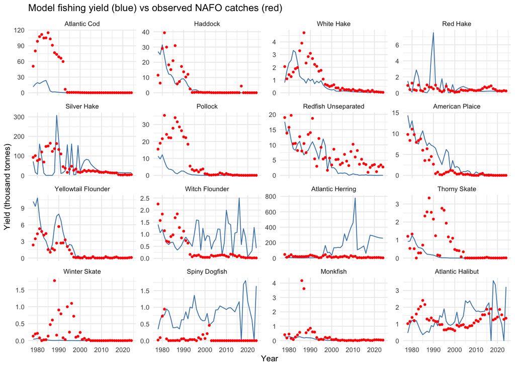

```r
yield_sim_base <- plotYieldGear(sim, return_data = T)

# Sum simulated yield across all gears per species per year
yield_sim_total <- yield_sim_base |> group_by(Year, Species) |>
  summarise(Yield_sim = sum(Yield, na.rm = TRUE), .groups = "drop")

# Sum fishing only (exclude seals) for comparison to NAFO catches
yield_sim_fishing <- yield_sim_base |>
  filter(Gear != "Seals") |>
  group_by(Year, Species) |>
  summarise(Yield_fishing = sum(Yield, na.rm = TRUE), .groups = "drop")

# Plot fishing yield vs observed
ggplot() +
  geom_line(data = filter(yield_sim_fishing, !Species %in% c("Sand Lance", "Capelin", "Longhorn Sculpin")),aes(x = Year, y = Yield_fishing / 1e9), colour = "steelblue") +
  geom_point(data = filter(yield_ts,!Species %in% c("Sand Lance", "Capelin", "Longhorn Sculpin")),
             aes(x = Year, y = Yield / 1e9), size = 0.8, colour = "red") +
  facet_wrap(~Species, scales = "free_y", ncol = 4) +
  labs(x = "Year", y = "Yield (thousand tonnes)",
       title = "Model fishing yield (blue) vs observed NAFO catches (red)") +
  theme_minimal(base_size = 8)
```

Test with Additional predation mortality on all spp Introduction of New gears (named: seal) params now include additional gear Seal diet roughly parameterised from info: https://waves-vagues.dfo-mpo.gc.ca/library-bibliotheque/41217913.pdf https://academic.oup.com/icesjms/article/71/6/1332/2835596 Bowen, W.D., 1.W. Lawson, and B. Beck. 1993. Seasonal and geographic variation in the species composition and sine sf prey consumed by grey seals (Halickoerus grypus) on the Scotian Shelf. Can. 1. Fish. Aquat. Sci. 50: 1768-1 778.

```r
# gaussian_sizeweight <- function(w, species_params, w_opt, sigma, ...) {
#   exp(-0.5 * ((log(w) - log(w_opt)) / sigma)^2)
# }
#
# seal_gear_params <- readRDS("Ess_data/seal_gear_params.RDS")
# params_with_seal <- params_steady
# orig_gears <- gear_params(params_steady)
#
# orig_gears$w_opt <- NA
# orig_gears$sigma <- NA
#
# seal_gears <- seal_gear_params[, c("species", "gear", "sel_func","catchability", "w_opt", "sigma")]
# seal_gears$knife_edge_size <- NA
#
# missing_cols <- setdiff(names(orig_gears), names(seal_gears))
# for(col in missing_cols) seal_gears[[col]] <- NA
# seal_gears <- seal_gears[, names(orig_gears)]
#
# all_gears <- rbind(orig_gears, seal_gears)
# gear_params(params_with_seal) <- all_gears
# #save object for later use ( params with additional predation mortality)
# saveRDS(params_with_seal,"Ess_data/params_with_seal_interaction.RDS")
```

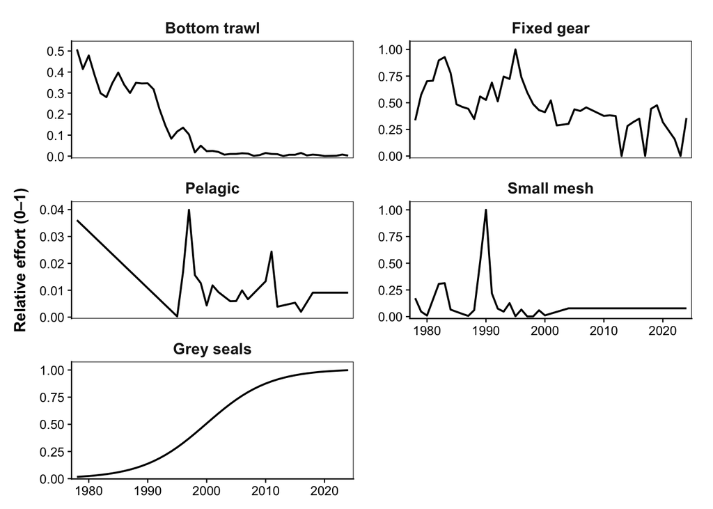

```r
fishing_history = read.csv("Ess_data/effort_gear_with_seals.csv",row.names = 1)
effort<-fishing_history[as.character("1978":"2024"),]
effort_with_seal <- as.matrix(effort)

# Add Year column from row names
effort$Year <- as.numeric(rownames(effort))
# Convert to long format
effort_long <- effort %>%pivot_longer(cols = -Year, names_to = "Gear",values_to = "Effort" )
# Rename for publication-style labels
effort_long$Gear <- factor(
  effort_long$Gear,
  levels = c("Bottom_Trawl", "Fixed_Gear", "Pelagic", "Small_Mesh", "Seals"),
  labels = c("Bottom trawl", "Fixed gear", "Pelagic","Small mesh", "Grey seals"))
# facet plot
p <- ggplot(effort_long, aes(x = Year, y = Effort)) +
  geom_line(linewidth = 0.65, colour = "black") +
  facet_wrap(~ Gear, scales = "free_y", ncol = 2) +
  scale_x_continuous(
    breaks = c(1980, 1990, 2000, 2010, 2020),
    labels = c("1980", "1990", "2000", "2010", "2020"),
    expand = expansion(mult = c(0.02, 0.02))) +
  scale_y_continuous(expand = expansion(mult = c(0.02, 0.08))) +
  labs(x = NULL, y = "Relative effort (0–1)") +
  theme_classic(base_size = 11) +
  theme(
    strip.background = element_rect(fill = "white", colour = NA),
    strip.text        = element_text(face = "bold", size = 11, hjust = 0.5),
    axis.title.y      = element_text(face = "bold", size = 11, margin = margin(r = 8)),
    axis.text         = element_text(colour = "black", size = 9),
    axis.line         = element_line(colour = "black", linewidth = 0.4),
    axis.ticks        = element_line(colour = "black", linewidth = 0.4),
    panel.border      = element_rect(colour = "black", fill = NA, linewidth = 0.4),
    panel.spacing.x   = unit(1.2, "lines"),
    panel.spacing.y   = unit(0.8, "lines"),
    plot.margin       = margin(10, 15, 8, 10)
  )
p
```

```r
#save effort forcing matrix object for later use
#saveRDS(effort_with_seal,"Ess_data/new_effort_with_seal_matrix.RDS")
```

```r
# plotYieldGear(sim,gears=c("Seals"))
```